# Glioma Grading Using Clinical and Mutation Features

2021ICT106

# 1. Introduction

Can five gene mutation indicators help tell lower-grade glioma (LGG) and glioblastoma (GBM) apart better than age alone? I used the prepared UCI glioma dataset to compare two logistic regression models.

- Model A uses age at diagnosis.
- Model B uses age and mutation status for IDH1, TP53, ATRX, EGFR and PTEN.

# 2. Setup

```r
# Load the plotting package.
library(ggplot2)
grade_colors <- c(LGG = "#E76F51", GBM = "#008C95")

# Identify the RStudio project folder.
root <- here::here()

# Create paths for folders.
data_dir <- file.path(root, "data")
fig_dir <- file.path(root, "figures")
results_dir <- file.path(root, "results")

# Ensure output folders exist.
dir.create(fig_dir, showWarnings = FALSE, recursive = TRUE)
dir.create(results_dir, showWarnings = FALSE, recursive = TRUE)

# R Markdown settings.
knitr::opts_chunk$set(
  echo = TRUE,
  message = FALSE
)
```

# 3. Data Import

```r
# Location of the official preprocessed UCI dataset.
input_file <- file.path(
  data_dir,
  "TCGA_InfoWithGrade.csv"
)

# Give a clear error if the file is missing.
if (!file.exists(input_file)) {
  stop("Place TCGA_InfoWithGrade.csv inside the data folder.")
}

# Import the CSV file with its header.
raw <- read.csv(input_file, check.names = FALSE)

# All 20 gene columns from the original dataset.
genes <- c(
  "IDH1", "TP53", "ATRX", "PTEN", "EGFR",
  "CIC", "MUC16", "PIK3CA", "NF1", "PIK3R1",
  "FUBP1", "RB1", "NOTCH1", "BCOR", "CSMD3",
  "SMARCA4", "GRIN2A", "IDH2", "FAT4", "PDGFRA"
)

# Check the expected original column names.
expected_columns <- c(
  "Grade",
  "Gender",
  "Age_at_diagnosis",
  "Race",
  genes
)

stopifnot(
  nrow(raw) == 839,
  ncol(raw) == 24,
  identical(names(raw), expected_columns)
)

# Examine the imported data.
dim(raw)
```

```
## [1] 839  24
```

```r
head(raw)
```

```
##   Grade Gender Age_at_diagnosis Race IDH1 TP53 ATRX PTEN EGFR CIC MUC16 PIK3CA
## 1     0      0            51.30    0    1    0    0    0    0   0     0      1
## 2     0      0            38.72    0    1    0    0    0    0   1     0      0
## 3     0      0            35.17    0    1    1    1    0    0   0     0      0
## 4     0      1            32.78    0    1    1    1    0    0   0     1      0
## 5     0      0            31.51    0    1    1    1    0    0   0     0      0
## 6     0      1            33.21    0    1    0    1    0    0   0     0      0
##   NF1 PIK3R1 FUBP1 RB1 NOTCH1 BCOR CSMD3 SMARCA4 GRIN2A IDH2 FAT4 PDGFRA
## 1   0      0     1   0      0    0     0       0      0    0    0      0
## 2   0      0     0   0      0    0     0       0      0    0    0      0
## 3   0      0     0   0      0    0     0       0      0    0    0      0
## 4   0      1     0   0      0    0     0       0      0    0    1      0
## 5   0      0     0   0      0    0     0       0      0    0    0      0
## 6   0      0     0   0      0    0     0       0      0    0    0      0
```

```r
str(raw)
```

```
## 'data.frame':    839 obs. of  24 variables:
##  $ Grade           : int  0 0 0 0 0 0 0 0 0 0 ...
##  $ Gender          : int  0 0 0 1 0 1 1 1 1 0 ...
##  $ Age_at_diagnosis: num  51.3 38.7 35.2 32.8 31.5 ...
##  $ Race            : int  0 0 0 0 0 0 0 0 0 0 ...
##  $ IDH1            : int  1 1 1 1 1 1 1 1 1 0 ...
##  $ TP53            : int  0 0 1 1 1 0 1 1 1 0 ...
##  $ ATRX            : int  0 0 1 1 1 1 0 1 1 0 ...
##  $ PTEN            : int  0 0 0 0 0 0 0 0 0 0 ...
##  $ EGFR            : int  0 0 0 0 0 0 0 0 0 0 ...
##  $ CIC             : int  0 1 0 0 0 0 0 0 0 0 ...
##  $ MUC16           : int  0 0 0 1 0 0 0 0 0 0 ...
##  $ PIK3CA          : int  1 0 0 0 0 0 0 0 0 0 ...
##  $ NF1             : int  0 0 0 0 0 0 0 0 0 0 ...
##  $ PIK3R1          : int  0 0 0 1 0 0 0 0 0 0 ...
##  $ FUBP1           : int  1 0 0 0 0 0 0 0 0 0 ...
##  $ RB1             : int  0 0 0 0 0 0 0 0 0 0 ...
##  $ NOTCH1          : int  0 0 0 0 0 0 0 0 0 0 ...
##  $ BCOR            : int  0 0 0 0 0 0 0 0 0 0 ...
##  $ CSMD3           : int  0 0 0 0 0 0 0 0 0 0 ...
##  $ SMARCA4         : int  0 0 0 0 0 0 0 0 0 0 ...
##  $ GRIN2A          : int  0 0 0 0 0 0 0 0 0 0 ...
##  $ IDH2            : int  0 0 0 0 0 0 0 0 0 0 ...
##  $ FAT4            : int  0 0 0 1 0 0 0 0 0 0 ...
##  $ PDGFRA          : int  0 0 0 0 0 0 0 0 0 0 ...
```

```r
summary(raw)
```

```
##      Grade            Gender       Age_at_diagnosis      Race
##  Min.   :0.0000   Min.   :0.0000   Min.   :14.42    Min.   :0.0000
##  1st Qu.:0.0000   1st Qu.:0.0000   1st Qu.:38.05    1st Qu.:0.0000
##  Median :0.0000   Median :0.0000   Median :51.55    Median :0.0000
##  Mean   :0.4195   Mean   :0.4184   Mean   :50.94    Mean   :0.1073
##  3rd Qu.:1.0000   3rd Qu.:1.0000   3rd Qu.:62.80    3rd Qu.:0.0000
##  Max.   :1.0000   Max.   :1.0000   Max.   :89.29    Max.   :3.0000
##       IDH1             TP53             ATRX             PTEN
##  Min.   :0.0000   Min.   :0.0000   Min.   :0.0000   Min.   :0.0000
##  1st Qu.:0.0000   1st Qu.:0.0000   1st Qu.:0.0000   1st Qu.:0.0000
##  Median :0.0000   Median :0.0000   Median :0.0000   Median :0.0000
##  Mean   :0.4815   Mean   :0.4148   Mean   :0.2586   Mean   :0.1681
##  3rd Qu.:1.0000   3rd Qu.:1.0000   3rd Qu.:1.0000   3rd Qu.:0.0000
##  Max.   :1.0000   Max.   :1.0000   Max.   :1.0000   Max.   :1.0000
##       EGFR             CIC             MUC16            PIK3CA
##  Min.   :0.0000   Min.   :0.0000   Min.   :0.0000   Min.   :0.00000
##  1st Qu.:0.0000   1st Qu.:0.0000   1st Qu.:0.0000   1st Qu.:0.00000
##  Median :0.0000   Median :0.0000   Median :0.0000   Median :0.00000
##  Mean   :0.1335   Mean   :0.1323   Mean   :0.1168   Mean   :0.08701
##  3rd Qu.:0.0000   3rd Qu.:0.0000   3rd Qu.:0.0000   3rd Qu.:0.00000
##  Max.   :1.0000   Max.   :1.0000   Max.   :1.0000   Max.   :1.00000
##       NF1              PIK3R1            FUBP1              RB1
##  Min.   :0.00000   Min.   :0.00000   Min.   :0.00000   Min.   :0.00000
##  1st Qu.:0.00000   1st Qu.:0.00000   1st Qu.:0.00000   1st Qu.:0.00000
##  Median :0.00000   Median :0.00000   Median :0.00000   Median :0.00000
##  Mean   :0.07986   Mean   :0.06436   Mean   :0.05364   Mean   :0.04768
##  3rd Qu.:0.00000   3rd Qu.:0.00000   3rd Qu.:0.00000   3rd Qu.:0.00000
##  Max.   :1.00000   Max.   :1.00000   Max.   :1.00000   Max.   :1.00000
##      NOTCH1             BCOR             CSMD3            SMARCA4
##  Min.   :0.00000   Min.   :0.00000   Min.   :0.00000   Min.   :0.00000
##  1st Qu.:0.00000   1st Qu.:0.00000   1st Qu.:0.00000   1st Qu.:0.00000
##  Median :0.00000   Median :0.00000   Median :0.00000   Median :0.00000
##  Mean   :0.04529   Mean   :0.03456   Mean   :0.03218   Mean   :0.03218
##  3rd Qu.:0.00000   3rd Qu.:0.00000   3rd Qu.:0.00000   3rd Qu.:0.00000
##  Max.   :1.00000   Max.   :1.00000   Max.   :1.00000   Max.   :1.00000
##      GRIN2A             IDH2              FAT4             PDGFRA
##  Min.   :0.00000   Min.   :0.00000   Min.   :0.00000   Min.   :0.00000
##  1st Qu.:0.00000   1st Qu.:0.00000   1st Qu.:0.00000   1st Qu.:0.00000
##  Median :0.00000   Median :0.00000   Median :0.00000   Median :0.00000
##  Mean   :0.03218   Mean   :0.02741   Mean   :0.02741   Mean   :0.02622
##  3rd Qu.:0.00000   3rd Qu.:0.00000   3rd Qu.:0.00000   3rd Qu.:0.00000
##  Max.   :1.00000   Max.   :1.00000   Max.   :1.00000   Max.   :1.00000
```

# 4. Data Quality Control and Preprocessing

```r
# Count missing values.
missing_values <- sum(is.na(raw))
cat("Missing values:", missing_values, "\n")
```

```
## Missing values: 0
```

```r
# Check for identical complete rows.
duplicate_rows <- sum(duplicated(raw))
cat("Identical rows:", duplicate_rows, "\n")
```

```
## Identical rows: 1
```

```r
# Confirm numerical column types.
numeric_columns <- c(
  "Grade", "Age_at_diagnosis", genes
)

stopifnot(all(vapply(
  raw[numeric_columns],
  is.numeric,
  logical(1)
)))

# Check the target uses the documented coding.
stopifnot(all(raw$Grade %in% c(0, 1)))

# Check mutation indicators only contain 0 or 1.
for (gene in genes) {
  stopifnot(all(raw[[gene]] %in% c(0, 1)))
}

# The official preprocessed dataset should be complete.
if (missing_values > 0) {
  stop("Unexpected missing data found.")
}

# Keep the original numeric target for modelling.
df <- raw

# Add readable labels for graphs and summaries.
df$GradeLabel <- factor(
  df$Grade,
  levels = c(0, 1),
  labels = c("LGG", "GBM")
)

# Save a copy with the additional readable label.
write.csv(
  df,
  file.path(data_dir, "cleaned_glioma.csv"),
  row.names = FALSE
)

# Count LGG and GBM records.
table(df$GradeLabel)
```

```
##
## LGG GBM
## 487 352
```

```r
# Display class proportions.
prop.table(table(df$GradeLabel))
```

```
##
##       LGG       GBM
## 0.5804529 0.4195471
```

# 5. Exploratory Data Analysis

## 5.1 Distribution of Glioma Classes

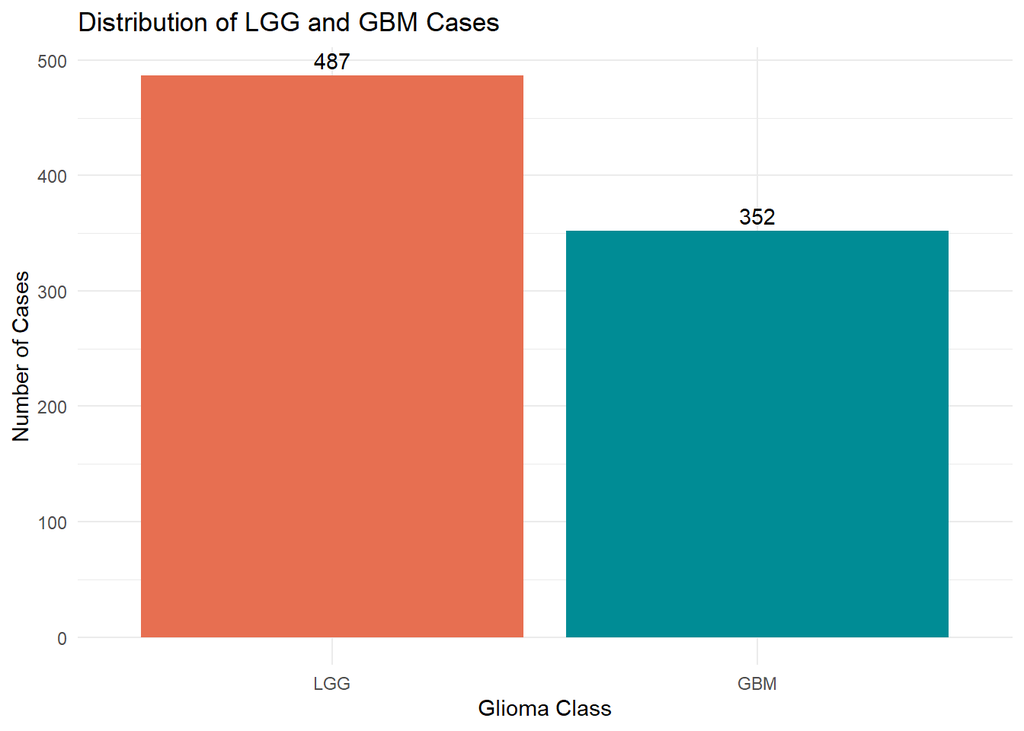

```r
# Convert a frequency table into a data frame.
class_counts <- as.data.frame(
  table(df$GradeLabel)
)

colnames(class_counts) <- c("Grade", "Count")

# Create the bar chart.
p1 <- ggplot(
  class_counts,
  aes(x = Grade, y = Count, fill = Grade)
) +
  geom_col() +
  geom_text(
    aes(label = Count),
    vjust = -0.4
  ) +
  labs(
    title = "Distribution of LGG and GBM Cases",
    x = "Glioma Class",
    y = "Number of Cases"
  ) +
  scale_fill_manual(values = grade_colors) +
  theme_minimal() +
  theme(legend.position = "none")

print(p1)
```

```r
# Save the figure.
ggsave(
  file.path(fig_dir, "01_grade_distribution.png"),
  plot = p1,
  width = 7,
  height = 5,
  dpi = 150
)
```

## 5.2 Age Distribution by Glioma Class

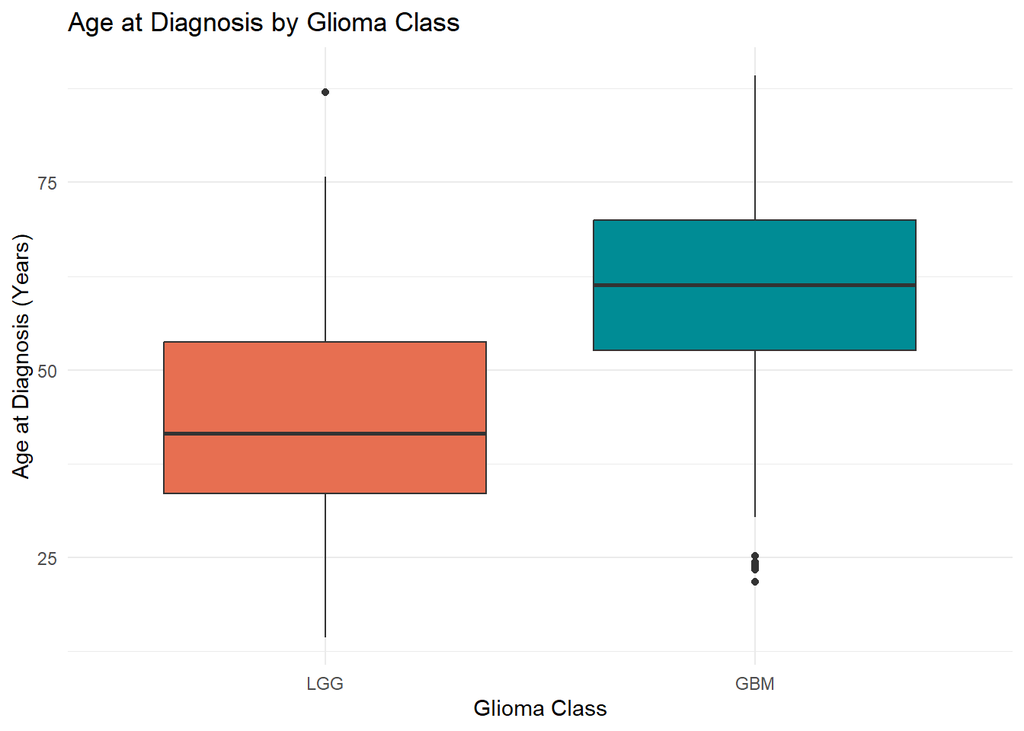

```r
# Compare age distributions using a boxplot.
p2 <- ggplot(
  df,
  aes(
    x = GradeLabel,
    y = Age_at_diagnosis,
    fill = GradeLabel
  )
) +
  geom_boxplot() +
  labs(
    title = "Age at Diagnosis by Glioma Class",
    x = "Glioma Class",
    y = "Age at Diagnosis (Years)"
  ) +
  scale_fill_manual(values = grade_colors) +
  theme_minimal() +
  theme(legend.position = "none")

print(p2)
```

```r
ggsave(
  file.path(fig_dir, "02_age_by_grade.png"),
  plot = p2,
  width = 7,
  height = 5,
  dpi = 150
)

# Summary statistics for each group.
aggregate(
  Age_at_diagnosis ~ GradeLabel,
  data = df,
  FUN = median
)
```

```
##   GradeLabel Age_at_diagnosis
## 1        LGG           41.610
## 2        GBM           61.395
```

## 5.3 Mutation Frequencies for All 20 Genes

```r
# Calculate the percentage of mutated samples
# separately in each glioma class for every gene.

mutation_rates <- do.call(
  rbind,
  lapply(genes, function(gene) {

    lgg_rate <- mean(
      df[[gene]][df$GradeLabel == "LGG"]
    ) * 100

    gbm_rate <- mean(
      df[[gene]][df$GradeLabel == "GBM"]
    ) * 100

    data.frame(
      Gene = gene,
      Grade = factor(c("LGG", "GBM"), levels = c("LGG", "GBM")),
      MutationPercent = c(lgg_rate, gbm_rate)
    )
  })
)

# Display the percentage table.
head(mutation_rates, 10)
```

```
##    Gene Grade MutationPercent
## 1  IDH1   LGG       78.234086
## 2  IDH1   GBM        6.534091
## 3  TP53   LGG       48.254620
## 4  TP53   GBM       32.102273
## 5  ATRX   LGG       37.577002
## 6  ATRX   GBM        9.659091
## 7  PTEN   LGG        5.133470
## 8  PTEN   GBM       32.954545
## 9  EGFR   LGG        6.365503
## 10 EGFR   GBM       23.011364
```

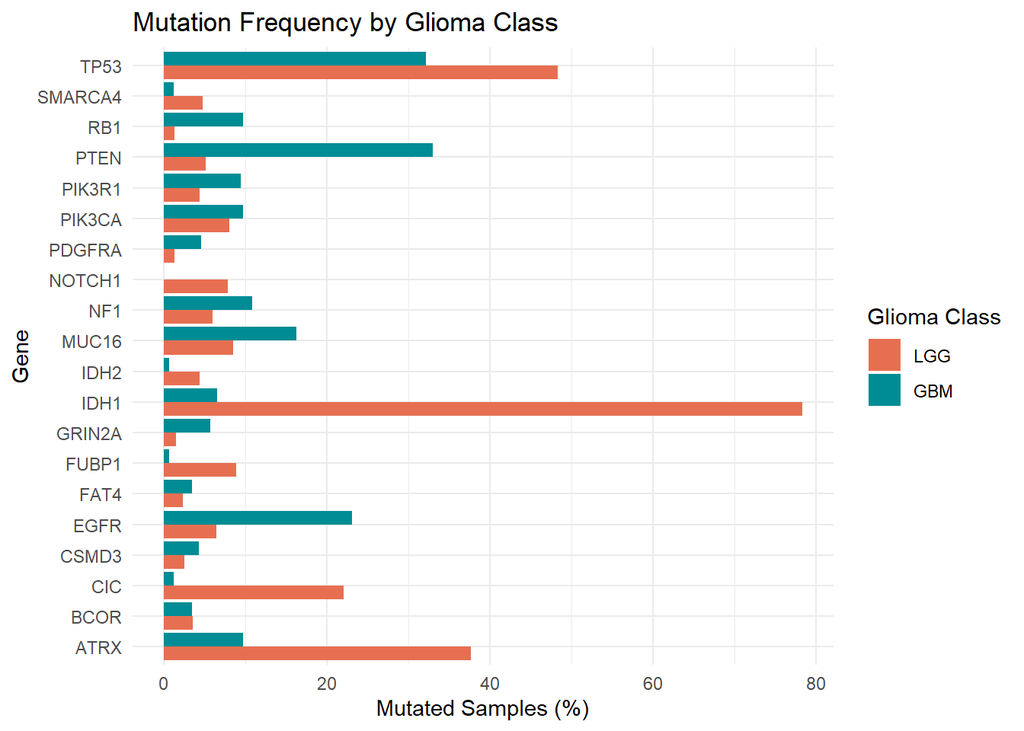

```r
# Save the table.
write.csv(
  mutation_rates,
  file.path(results_dir, "mutation_frequencies.csv"),
  row.names = FALSE
)

# Plot mutations for all 20 genes.
p3 <- ggplot(
  mutation_rates,
  aes(
    x = Gene,
    y = MutationPercent,
    fill = Grade
  )
) +
  geom_col(position = "dodge") +
  coord_flip() +
  labs(
    title = "Mutation Frequency by Glioma Class",
    x = "Gene",
    y = "Mutated Samples (%)",
    fill = "Glioma Class"
  ) +
  scale_fill_manual(values = grade_colors) +
  theme_minimal()

print(p3)
```

```r
ggsave(
  file.path(fig_dir, "03_mutation_frequency.png"),
  plot = p3,
  width = 10,
  height = 9,
  dpi = 150
)
```

# 6. Statistical Analysis

## 6.1 IDH1 Mutation and Glioma Class

```r
# Create a contingency table.
idh1_table <- table(
  Grade = df$GradeLabel,
  IDH1_Mutation = df$IDH1
)

idh1_table
```

```
##      IDH1_Mutation
## Grade   0   1
##   LGG 106 381
##   GBM 329  23
```

```r
# Test whether IDH1 mutation status and
# the glioma class are statistically associated.
idh1_test <- fisher.test(idh1_table)

# Display the p-value and odds-ratio estimate.
idh1_test
```

```
##
##  Fisher's Exact Test for Count Data
##
## data:  idh1_table
## p-value < 2.2e-16
## alternative hypothesis: true odds ratio is not equal to 1
## 95 percent confidence interval:
##  0.01163625 0.03175141
## sample estimates:
## odds ratio
## 0.01958882
```

```r
cat("Exact p-value:", format(idh1_test$p.value, scientific = TRUE), "\n")
```

```
## Exact p-value: 4.348595e-106
```

# 7. Machine Learning

## 7.1 Split Into Training and Testing Data

```r
# Set a fixed random seed for reproducibility.
set.seed(123)

# Find row indices for each class.
lgg_ids <- which(df$Grade == 0)
gbm_ids <- which(df$Grade == 1)

# Select approximately 80% within each class.
train_lgg <- sample(
  lgg_ids,
  floor(0.8 * length(lgg_ids))
)

train_gbm <- sample(
  gbm_ids,
  floor(0.8 * length(gbm_ids))
)

# Combine selected indices.
train_ids <- sort(c(train_lgg, train_gbm))

# Create independent training and test subsets.
train <- df[train_ids, ]
test <- df[-train_ids, ]

# Verify their sizes.
cat("Training samples:", nrow(train), "\n")
```

```
## Training samples: 670
```

```r
cat("Testing samples:", nrow(test), "\n")
```

```
## Testing samples: 169
```

```r
# Display the class distribution in each subset.
table(train$GradeLabel)
```

```
##
## LGG GBM
## 389 281
```

```r
table(test$GradeLabel)
```

```
##
## LGG GBM
##  98  71
```

```r
stopifnot(nrow(train) == 670)
stopifnot(nrow(test) == 169)
```

## 7.2 Model A: Age Only

```r
# Logistic regression using just age.
model_age <- glm(
  Grade ~ Age_at_diagnosis,
  data = train,
  family = binomial()
)

# Inspect fitted coefficients.
summary(model_age)
```

```
##
## Call:
## glm(formula = Grade ~ Age_at_diagnosis, family = binomial(),
##     data = train)
##
## Coefficients:
##                   Estimate Std. Error z value Pr(>|z|)
## (Intercept)      -5.071064   0.410193  -12.36   <2e-16 ***
## Age_at_diagnosis  0.091267   0.007522   12.13   <2e-16 ***
## ---
## Signif. codes:  0 '***' 0.001 '**' 0.01 '*' 0.05 '.' 0.1 ' ' 1
##
## (Dispersion parameter for binomial family taken to be 1)
##
##     Null deviance: 911.33  on 669  degrees of freedom
## Residual deviance: 694.82  on 668  degrees of freedom
## AIC: 698.82
##
## Number of Fisher Scoring iterations: 4
```

## 7.3 Model B: Age and Selected Gene Mutations

The model uses IDH1, TP53 and ATRX, which were more often mutated in LGG, and EGFR and PTEN, which were more often mutated in GBM. This gives the model a small set of genes with patterns in both groups.

```r
# The second model uses age and five genes.
# Mutation columns are binary indicators (0 or 1).

model_genes <- glm(
  Grade ~ Age_at_diagnosis +
    IDH1 +
    TP53 +
    ATRX +
    EGFR +
    PTEN,
  data = train,
  family = binomial()
)

# View coefficients and statistical information.
summary(model_genes)
```

```
##
## Call:
## glm(formula = Grade ~ Age_at_diagnosis + IDH1 + TP53 + ATRX +
##     EGFR + PTEN, family = binomial(), data = train)
##
## Coefficients:
##                   Estimate Std. Error z value Pr(>|z|)
## (Intercept)      -2.331483   0.557949  -4.179 2.93e-05 ***
## Age_at_diagnosis  0.054231   0.009471   5.726 1.03e-08 ***
## IDH1             -3.678796   0.358583 -10.259  < 2e-16 ***
## TP53              1.317684   0.361970   3.640 0.000272 ***
## ATRX             -0.262831   0.392749  -0.669 0.503363
## EGFR             -0.100189   0.304574  -0.329 0.742194
## PTEN              0.610916   0.304683   2.005 0.044954 *
## ---
## Signif. codes:  0 '***' 0.001 '**' 0.01 '*' 0.05 '.' 0.1 ' ' 1
##
## (Dispersion parameter for binomial family taken to be 1)
##
##     Null deviance: 911.33  on 669  degrees of freedom
## Residual deviance: 473.53  on 663  degrees of freedom
## AIC: 487.53
##
## Number of Fisher Scoring iterations: 5
```

## 7.4 Generate Test Predictions

```r
# Predict probabilities of GBM for the test set.

prob_age <- predict(
  model_age,
  newdata = test,
  type = "response"
)

prob_genes <- predict(
  model_genes,
  newdata = test,
  type = "response"
)

# Confirm probabilities are valid.
stopifnot(
  all(is.finite(prob_age)),
  all(is.finite(prob_genes)),
  all(prob_age >= 0 & prob_age <= 1),
  all(prob_genes >= 0 & prob_genes <= 1)
)

# Display some predicted probabilities.
head(prob_genes)
```

```
##          1          6         15         17         19         28
## 0.03811782 0.01129443 0.38506768 0.04377398 0.06916316 0.01800675
```

# 8. Model Evaluation

## 8.1 Evaluation Function

```r
# This function calculates performance for either model.
# The positive class is GBM.

evaluate_model <- function(actual, probabilities, name) {

  # Convert probabilities into 0/1 predictions.
  predicted <- ifelse(probabilities >= 0.5, 1, 0)

  # Create confusion matrix with a fixed class order.
  cm <- table(
    Actual = factor(
      actual,
      levels = c(0, 1),
      labels = c("LGG", "GBM")
    ),
    Predicted = factor(
      predicted,
      levels = c(0, 1),
      labels = c("LGG", "GBM")
    )
  )

  # Extract confusion matrix components.
  TP <- cm["GBM", "GBM"]
  TN <- cm["LGG", "LGG"]
  FP <- cm["LGG", "GBM"]
  FN <- cm["GBM", "LGG"]

  # Avoid division-by-zero errors.
  safe_divide <- function(a, b) {
    if (b == 0) return(NA_real_)
    a / b
  }

  # Calculate metrics.
  accuracy <- safe_divide(TP + TN, sum(cm))
  precision <- safe_divide(TP, TP + FP)
  recall <- safe_divide(TP, TP + FN)
  specificity <- safe_divide(TN, TN + FP)

  # Calculate the F1-score.
  if (
    is.na(precision) ||
    is.na(recall) ||
    precision + recall == 0
  ) {
    f1 <- NA_real_
  } else {
    f1 <- 2 * precision * recall / (precision + recall)
  }

  # Return evaluation results.
  list(
    confusion = cm,
    metrics = data.frame(
      Model = name,
      Accuracy = round(accuracy, 4),
      Precision = round(precision, 4),
      Recall = round(recall, 4),
      Specificity = round(specificity, 4),
      F1 = round(f1, 4)
    )
  )
}
```

## 8.2 Evaluate Both Models

```r
# Evaluate baseline age-only model.
eval_age <- evaluate_model(
  test$Grade,
  prob_age,
  "Age only"
)

# Evaluate age + mutation model.
eval_genes <- evaluate_model(
  test$Grade,
  prob_genes,
  "Age + 5 genes"
)

# Combine metric tables.
comparison <- rbind(
  eval_age$metrics,
  eval_genes$metrics
)

# Display and save the comparison.
knitr::kable(comparison, digits = 4)
```

| Model | Accuracy | Precision | Recall | Specificity | F1 |
| --- | --- | --- | --- | --- | --- |
| Age only | 0.7278 | 0.6761 | 0.6761 | 0.7653 | 0.6761 |
| Age + 5 genes | 0.8580 | 0.7901 | 0.9014 | 0.8265 | 0.8421 |

```r
write.csv(
  comparison,
  file.path(results_dir, "model_comparison.csv"),
  row.names = FALSE
)
```

## 8.3 Confusion Matrix for Main Model

```r
# Print the actual and predicted classes.
eval_genes$confusion
```

```
##       Predicted
## Actual LGG GBM
##    LGG  81  17
##    GBM   7  64
```

```r
# Save the matrix as a CSV file.
write.csv(
  as.data.frame.matrix(eval_genes$confusion),
  file.path(results_dir, "confusion_matrix.csv")
)
```

## 8.4 Visualise the Confusion Matrix

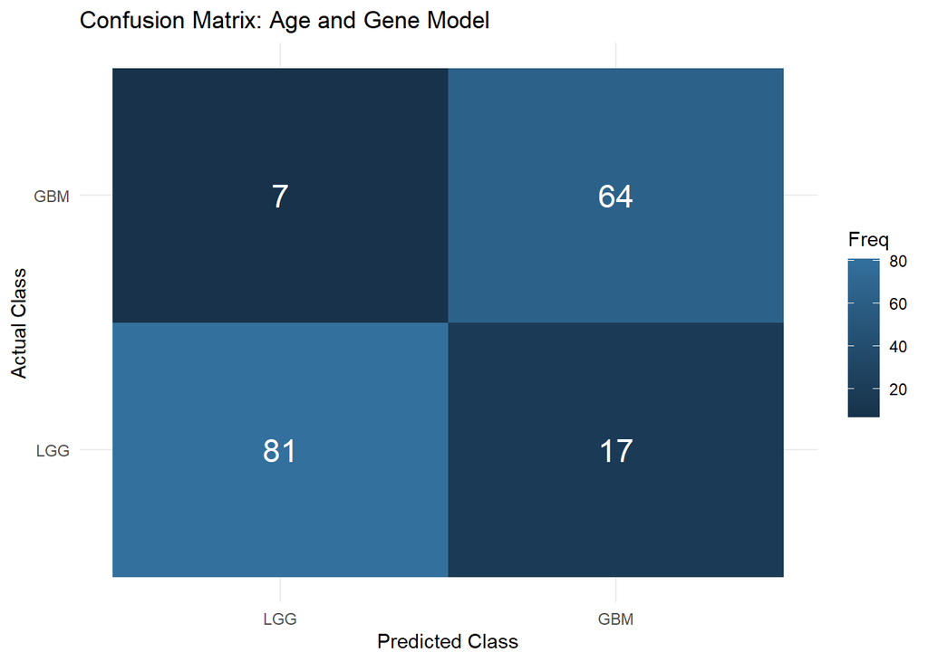

```r
cm_df <- as.data.frame(eval_genes$confusion)

p4 <- ggplot(
  cm_df,
  aes(
    x = Predicted,
    y = Actual,
    fill = Freq
  )
) +
  geom_tile() +
  geom_text(
    aes(label = Freq),
    color = "white",
    size = 6
  ) +
  scale_fill_gradient(low = "#17324A", high = "#33709D") +
  labs(
    title = "Confusion Matrix: Age and Gene Model",
    x = "Predicted Class",
    y = "Actual Class"
  ) +
  theme_minimal()

print(p4)
```

```r
ggsave(
  file.path(fig_dir, "04_confusion_matrix.png"),
  plot = p4,
  width = 7,
  height = 5,
  dpi = 150
)
```

# 9. What the results show

IDH1 mutations were much more common in the LGG group. Fisher’s exact test shows an association between IDH1 status and recorded grade.

On the same 169 test cases, the age-only model got 123 right and the age-plus-five-gene model got 145 right. The second model found 64 of 71 GBM cases, compared with 48 for age alone.

This comparison uses one split of a historical dataset. Testing on a separate dataset would help show whether the results hold elsewhere.